# Notebook

## MULTIMODAL FUSION FOR ED MISDIAGNOSIS PREDICTION

## Goal: Predict if the working ED diagnosis is discordant with the final

```
- discharge diagnosis using late fusion of BiLSTM text embeddings and
- transformer-based time-series features.
```

## Outputs:

```
- y_critical: Binary label (1 = missed high-severity diagnosis)
- Calibrated probabilities via temperature scaling
```

- 0. Setup and Configuration
- 0.1. Mount Drive and Install Dependencies

```python
# Mount Google Drive
from google.colab import drive
drive.mount('/content/drive')
```

- 0.2. Imports

```python
# Core Libraries
import os, sys, math, random, gc, glob
from pathlib import Path
from collections import Counter

# Data Processing
import numpy as np
import pandas as pd

# PyTorch
import torch
import torch.nn as nn
import torch.nn.functional as F
from torch.utils.data import Dataset, DataLoader

# Sklearn Utilities
from sklearn.preprocessing import StandardScaler
from sklearn.metrics import (
    roc_auc_score, f1_score, precision_score,
    recall_score, accuracy_score, confusion_matrix,
    roc_curve, auc
)
from sklearn.calibration import calibration_curve

# Visualization
import matplotlib.pyplot as plt
import seaborn as sns
sns.set(style="whitegrid")
plt.style.use("seaborn-v0_8-whitegrid")

print(" All packages imported successfully")
```

```
 All packages imported successfully
```

- 0.3. Configuration

```python
# PATHS
# Root directory for embeddings
DRIVE_ROOT = "/content/drive/MyDrive/Embed"

# Text embeddings (BiLSTM outputs)
TEXT_EMB_ZIP = f"{DRIVE_ROOT}/text_embedding.zip"

# Time-series embeddings (Transformer outputs)
TIME_EMB_ZIP = f"{DRIVE_ROOT}/time_embedding.zip"

# Working directory
WORK_DIR = "/content/medfusion_work"

# Output directories
BASE_OUT_DIR = Path(WORK_DIR) / "fusion_outputs"
PLOTS_DIR = BASE_OUT_DIR / "plots"
CALIB_DIR = BASE_OUT_DIR / "calibration"
MODEL_DIR = BASE_OUT_DIR / "models"

# Create all directories
for d in [WORK_DIR, BASE_OUT_DIR, PLOTS_DIR, CALIB_DIR, MODEL_DIR]:
    Path(d).mkdir(parents=True, exist_ok=True)

# HYPERPARAMETERS
SEED = 42
BATCH_SIZE = 128
HIDDEN_DIM = 256
DROPOUT = 0.3
LEARNING_RATE = 1e-3
WEIGHT_DECAY = 1e-4
N_EPOCHS = 20
PATIENCE = 5

# DEVICE
device = torch.device("cuda" if torch.cuda.is_available() else "cpu")
print(f" Using device: {device}")

# Set random seeds for reproducibility
random.seed(SEED)
np.random.seed(SEED)
torch.manual_seed(SEED)
if torch.cuda.is_available():
    torch.cuda.manual_seed_all(SEED)

print(" Configuration complete")
```

```
 Using device: cuda
 Configuration complete
```

- 0.4. Helper Functions

```python
def clear_gpu():
    """Clear GPU memory cache."""
    gc.collect()
    if torch.cuda.is_available():
        torch.cuda.empty_cache()

def find_file(base_dir, filename):
    """Recursively search for a file in base_dir."""
    files = glob.glob(f"{base_dir}/**/{filename}", recursive=True)
    if not files:
        raise FileNotFoundError(f"Could not find {filename} in {base_dir}")
    return files[0]

def fam3(code):
    """Extract 3-character ICD family code."""
    if pd.isna(code):
        return None
    return str(code).replace('.', '').upper()[:3]

print(" Helper functions loaded")
```

```
 Helper functions loaded
```

- 1. Data Extraction and File Location
- 1.1. Unzip Embedding Files

```python
import shutil

print("="*60)
print("STEP 1: EXTRACTING EMBEDDING FILES")
print("="*60)

# Clean up previous work directory if exists
if os.path.exists(WORK_DIR):
    print(f"Removing existing work directory: {WORK_DIR}")
    shutil.rmtree(WORK_DIR)

os.makedirs(WORK_DIR, exist_ok=True)

# Unzip text embeddings
if os.path.exists(TEXT_EMB_ZIP):
    print("\n[1/2] Unzipping text embeddings...")
    shutil.unpack_archive(TEXT_EMB_ZIP, f"{WORK_DIR}/text")
    print(" Text embeddings extracted")
else:
    raise FileNotFoundError(f"Text embeddings not found: {TEXT_EMB_ZIP}")

# Unzip time-series embeddings
if os.path.exists(TIME_EMB_ZIP):
    print("\n[2/2] Unzipping time-series embeddings...")
    shutil.unpack_archive(TIME_EMB_ZIP, f"{WORK_DIR}/time")
    print(" Time-series embeddings extracted")
else:
    raise FileNotFoundError(f"Time embeddings not found: {TIME_EMB_ZIP}")

print("\n All files extracted successfully")
```

```
============================================================
STEP 1: EXTRACTING EMBEDDING FILES
============================================================
Removing existing work directory: /content/medfusion_work

[1/2] Unzipping text embeddings...
 Text embeddings extracted

[2/2] Unzipping time-series embeddings...
 Time-series embeddings extracted

 All files extracted successfully
```

- 1.2. Locate Embedding Files

```python
# File naming conventions
TEXT_FILES = {
    "train": "bilstm_embeddings_train.npz",
    "val": "bilstm_embeddings_val.npz",
    "test": "bilstm_embeddings_test.npz"
}

TIME_FILES = {
    "train": "train_windows_transformer_features_all_ablation_merged_1205.parquet",
    "val": "val_windows_transformer_features_all_ablation_merged_1205.parquet",
    "test": "test_windows_transformer_features_all_ablation_merged_1205.parquet"
}

# Base directories
BASE_TEXT_DIR = f"{WORK_DIR}/text/"
BASE_TIME_DIR = f"{WORK_DIR}/time/Time Series Window/"

print("\n" + "="*60)
print("LOCATING EMBEDDING FILES")
print("="*60)

# Locate text embeddings
print("\n--- Text Embeddings (BiLSTM) ---")
text_train_path = find_file(BASE_TEXT_DIR, TEXT_FILES["train"])
text_val_path = find_file(BASE_TEXT_DIR, TEXT_FILES["val"])
text_test_path = find_file(BASE_TEXT_DIR, TEXT_FILES["test"])

print(f" Train: {os.path.basename(text_train_path)}")
print(f" Val:   {os.path.basename(text_val_path)}")
print(f" Test:  {os.path.basename(text_test_path)}")

# Locate time-series embeddings
print("\n--- Time-Series Features (Transformer) ---")
time_train_path = find_file(BASE_TIME_DIR, TIME_FILES["train"])
time_val_path = find_file(BASE_TIME_DIR, TIME_FILES["val"])
time_test_path = find_file(BASE_TIME_DIR, TIME_FILES["test"])

print(f" Train: {os.path.basename(time_train_path)}")
print(f" Val:   {os.path.basename(time_val_path)}")
print(f" Test:  {os.path.basename(time_test_path)}")

print("\n All files located successfully")
```

```
============================================================
LOCATING EMBEDDING FILES
============================================================

--- Text Embeddings (BiLSTM) ---
 Train: bilstm_embeddings_train.npz
 Val:   bilstm_embeddings_val.npz
 Test:  bilstm_embeddings_test.npz

--- Time-Series Features (Transformer) ---
 Train: train_windows_transformer_features_all_ablation_merged_1205.parquet
 Val:   val_windows_transformer_features_all_ablation_merged_1205.parquet
 Test:  test_windows_transformer_features_all_ablation_merged_1205.parquet

 All files located successfully
```

- 1.3. Diagnostic File Listing

```python
print("\n" + "="*60)
print("DIAGNOSTIC: COMPLETE FILE STRUCTURE")
print("="*60)

search_dir = f"{WORK_DIR}/time"

if os.path.exists(search_dir):
    files_found = []
    for root, dirs, files in os.walk(search_dir):
        for file in files:
            full_path = os.path.join(root, file)
            files_found.append(full_path)
            print(f"📄 {full_path}")

    if not files_found:
        print("⚠ WARNING: Folder exists but is EMPTY")
else:
    print(f" ERROR: Folder {search_dir} does not exist")
```

```
============================================================
DIAGNOSTIC: COMPLETE FILE STRUCTURE
============================================================
📄 /content/medfusion_work/time/Time Series Window/train_windows_transformer_features_all_ablation_merged_1205.parquet
📄 /content/medfusion_work/time/Time Series Window/test_windows_transformer_features_all_ablation_merged_1205.parquet
📄 /content/medfusion_work/time/Time Series Window/val_windows_transformer_features_all_ablation_merged_1205.parquet
```

- 2. Data Loading and Alignment
- 2.1. Data Loading Functions

```python
print("\n" + "="*60)
print("STEP 2: DATA LOADING & ALIGNMENT")
print("="*60)

# Column naming conventions
# Column naming conventions
ID_COL = "stay_id"
LABEL_COL = "y_critical"

# **FIXED**: Exclude ALL label and metadata columns
EXCLUDE_TIME_COLS = {
    # IDs and metadata
    "stay_id",
    "hadm_id",
    "subject_id",
    "split",
    "window_idx",
    "ablation",
    # **CRITICAL: ALL LABEL COLUMNS**
    "y",                # ← THIS WAS THE PROBLEM!
    "y_critical",
    "y_any_missed",
    "y_severity_2plus",
    "y_severity_3plus",
    "y_severity_6plus",
    "y_critical_2plus",
    "y_none_covered",
    "label",
}

def load_text_npz(path):
    """
    Load text embeddings from BiLSTM NPZ file.

    Returns:
    --------
    embeddings : np.ndarray (N, 256)
        Text embedding vectors
    labels : np.ndarray (N,)
        Binary labels (y_critical)
    stay_ids : np.ndarray (N,)
        Stay identifiers
    """
    data = np.load(path)
    emb = data["embeddings"]
    labels = data["labels"]
    stays = data["stay_ids"]

    print(f"  Text shape: {emb.shape}, Labels: {labels.shape}, IDs: {stays.shape}")
    return emb, labels, stays

def load_time_parquet(path):
    """
    Load time-series features from Parquet file.

    Returns:
    --------
    df : pd.DataFrame
        Full dataframe with stay_id and features
    feature_cols : list
        Column names of numeric features (excluding IDs/metadata)
    """
    df = pd.read_parquet(path)
    assert ID_COL in df.columns, f"{ID_COL} not found in time-series file!"

    # Select numeric columns, exclude metadata
    numeric_cols = df.select_dtypes(include=[np.number]).columns.tolist()
    feature_cols = [c for c in numeric_cols if c not in EXCLUDE_TIME_COLS]

    print(f"  Time shape: {df.shape}, Features: {len(feature_cols)}")

    if LABEL_COL not in df.columns:
        print(f"  ℹ Note: '{LABEL_COL}' not in file - will use labels from text NPZ")

    return df, feature_cols

print(" Data loading functions defined")
```

```
============================================================
STEP 2: DATA LOADING & ALIGNMENT
============================================================
 Data loading functions defined
```

```python
# Verify 'y' is excluded
print("="*60)
print("VERIFICATION: Label Column Excluded")
print("="*60)

df_check = pd.read_parquet(time_train_path)
numeric_cols = df_check.select_dtypes(include=[np.number]).columns.tolist()
feature_cols = [c for c in numeric_cols if c not in EXCLUDE_TIME_COLS]

print(f"Total numeric columns: {len(numeric_cols)}")
print(f"Excluded columns: {[c for c in numeric_cols if c in EXCLUDE_TIME_COLS]}")
print(f"Feature columns used: {len(feature_cols)}")

if 'y' in feature_cols:
    print("\n ERROR: 'y' still in features!")
else:
    print("\n SUCCESS: 'y' properly excluded")

print(f"\nTime feature dimension should now be: {len(feature_cols)} (was 66)")
```

```
============================================================
VERIFICATION: Label Column Excluded
============================================================
Total numeric columns: 69
Excluded columns: ['hadm_id', 'subject_id', 'y', 'window_idx', 'stay_id']
Feature columns used: 64

 SUCCESS: 'y' properly excluded

Time feature dimension should now be: 64 (was 66)
```

- 2.2. Alignment and Standardization

```python
def build_joint_split_with_scaling(text_path, time_path, scaler=None, fit_scaler=False):
    """
    Align text and time-series data by stay_id with proper feature scaling.

    CRITICAL: This function applies StandardScaler to normalize time-series
    features, which is essential for model convergence.

    Parameters:
    -----------
    text_path : str
        Path to text embeddings NPZ file
    time_path : str
        Path to time-series Parquet file
    scaler : StandardScaler or None
        Pre-fitted scaler (for val/test sets)
    fit_scaler : bool
        If True, fit new scaler on this data (train set only)

    Returns:
    --------
    X_text : np.ndarray (N_aligned, 256)
        Text embeddings for aligned samples
    X_time : np.ndarray (N_aligned, n_features)
        **STANDARDIZED** time-series features
    y : np.ndarray (N_aligned,)
        Binary labels
    scaler : StandardScaler
        Fitted scaler (if fit_scaler=True) or input scaler
    """
    split_name = os.path.basename(text_path).split('_')[2].replace('.npz', '')
    print(f"\n--- Processing {split_name.upper()} split ---")

    # Load text modality
    text_emb, text_labels, text_stays = load_text_npz(text_path)

    # Load time-series modality
    ts_df, ts_feat_cols = load_time_parquet(time_path)
    ts_index = {int(sid): i for i, sid in enumerate(ts_df[ID_COL].values)}

    # Align by stay_id
    X_text_list, X_time_list, y_list = [], [], []
    missing = 0

    for emb_vec, label, sid in zip(text_emb, text_labels, text_stays):
        sid = int(sid)
        if sid in ts_index:
            j = ts_index[sid]
            ts_row = ts_df.iloc[j]

            # Handle label mismatch (prefer time-series label if present)
            if LABEL_COL in ts_df.columns:
                ts_label = int(ts_row[LABEL_COL])
                if ts_label != int(label):
                    label = ts_label

            X_text_list.append(emb_vec.astype(np.float32))
            X_time_list.append(ts_row[ts_feat_cols].values.astype(np.float32))
            y_list.append(int(label))
        else:
            missing += 1

    if missing > 0:
        pct_missing = 100 * missing / len(text_stays)
        print(f"  ⚠ Dropped {missing} stays ({pct_missing:.1f}%) - no matching time-series")

    X_text = np.vstack(X_text_list)
    X_time = np.vstack(X_time_list)
    y = np.array(y_list, dtype=np.int64)

    # CRITICAL: STANDARDIZE TIME-SERIES FEATURES
    if fit_scaler:
        scaler = StandardScaler()
        X_time = scaler.fit_transform(X_time)
        print(f"   Fitted StandardScaler")
        print(f"    - Mean (first 5 features): {scaler.mean_[:5]}")
        print(f"    - Std (first 5 features): {scaler.scale_[:5]}")
    elif scaler is not None:
        X_time = scaler.transform(X_time)
        print(f"   Applied StandardScaler")
    else:
        print("  ⚠ WARNING: No scaling applied - model may fail to converge!")

    print(f"   Aligned data: text{X_text.shape}, time{X_time.shape}, labels{y.shape}")

    return X_text, X_time.astype(np.float32), y, scaler

print(" Alignment function defined")
```

```
 Alignment function defined
```

- 2.3. Build All Splits

```python
print("\n" + "="*60)
print("BUILDING ALIGNED DATASETS")
print("="*60)

# Train set - FIT scaler here
Xtr_text, Xtr_time, ytr, time_scaler = build_joint_split_with_scaling(
    text_train_path, time_train_path,
    scaler=None, fit_scaler=True
)

# Validation set - APPLY scaler
Xv_text, Xv_time, yv, _ = build_joint_split_with_scaling(
    text_val_path, time_val_path,
    scaler=time_scaler, fit_scaler=False
)

# Test set - APPLY scaler
Xs_text, Xs_time, ys, _ = build_joint_split_with_scaling(
    text_test_path, time_test_path,
    scaler=time_scaler, fit_scaler=False
)

text_dim = Xtr_text.shape[1]
time_dim = Xtr_time.shape[1]

print("\n" + "="*60)
print(" ALIGNMENT COMPLETE")
print("="*60)
print(f"Text embedding dimension: {text_dim}")
print(f"Time feature dimension: {time_dim}")
print(f"Train samples: {Xtr_text.shape[0]:,}")
print(f"Val samples: {Xv_text.shape[0]:,}")
print(f"Test samples: {Xs_text.shape[0]:,}")
```

```
============================================================
BUILDING ALIGNED DATASETS
============================================================

--- Processing TRAIN split ---
  Text shape: (141300, 256), Labels: (141300,), IDs: (141300,)
  Time shape: (530808, 71), Features: 64
  ℹ Note: 'y_critical' not in file - will use labels from text NPZ
  ⚠ Dropped 8599 stays (6.1%) - no matching time-series
   Fitted StandardScaler
    - Mean (first 5 features): [0.25093573 0.58346702 0.04104002 0.20284635 0.22128028]
    - Std (first 5 features): [0.40871182 1.16157993 0.34937567 1.38100763 0.38476688]
   Aligned data: text(132701, 256), time(132701, 64), labels(132701,)

--- Processing VAL split ---
  Text shape: (30273, 256), Labels: (30273,), IDs: (30273,)
  Time shape: (113432, 71), Features: 64
  ℹ Note: 'y_critical' not in file - will use labels from text NPZ
  ⚠ Dropped 1915 stays (6.3%) - no matching time-series
   Applied StandardScaler
   Aligned data: text(28358, 256), time(28358, 64), labels(28358,)

--- Processing TEST split ---
  Text shape: (29923, 256), Labels: (29923,), IDs: (29923,)
  Time shape: (112400, 71), Features: 64
  ℹ Note: 'y_critical' not in file - will use labels from text NPZ
  ⚠ Dropped 1823 stays (6.1%) - no matching time-series
   Applied StandardScaler
   Aligned data: text(28100, 256), time(28100, 64), labels(28100,)

============================================================
 ALIGNMENT COMPLETE
============================================================
Text embedding dimension: 256
Time feature dimension: 64
Train samples: 132,701
Val samples: 28,358
Test samples: 28,100
```

- 2.4. Verify Standardization

```python
print("\n" + "="*60)
print("VERIFICATION: FEATURE STANDARDIZATION")
print("="*60)

print("\n--- Train Set Time Features (After Scaling) ---")
print(f"Mean (first 5): {Xtr_time[:, :5].mean(axis=0)}")
print(f"Std (first 5): {Xtr_time[:, :5].std(axis=0)}")

print("\n--- Val Set Time Features (After Scaling) ---")
print(f"Mean (first 5): {Xv_time[:, :5].mean(axis=0)}")
print(f"Std (first 5): {Xv_time[:, :5].std(axis=0)}")

print("\n Verification complete: Features properly standardized")
print("  (Mean ≈ 0, Std ≈ 1 confirms successful scaling)")
```

```
============================================================
VERIFICATION: FEATURE STANDARDIZATION
============================================================

--- Train Set Time Features (After Scaling) ---
Mean (first 5): [ 8.9895886e-09 -9.0955915e-10  5.0028000e-09  3.1677306e-08
 -2.7596698e-09]
Std (first 5): [0.99997604 0.9999959  0.99998575 0.99999774 0.99999076]

--- Val Set Time Features (After Scaling) ---
Mean (first 5): [-0.0049883  -0.01659109  0.01263097 -0.01806982 -0.00902802]
Std (first 5): [1.0107129 0.9987837 0.9935763 0.9997688 1.0022057]

 Verification complete: Features properly standardized
  (Mean ≈ 0, Std ≈ 1 confirms successful scaling)
```

- 3. Data Alignment Visualization
- 3.1. Alignment Statistics Plot

```
============================================================
VISUALIZATION: DATA ALIGNMENT
============================================================
✓ Output directory verified: /content/medfusion_work/fusion_outputs/plots

Split  Original (Text)  Aligned (Both)  Dropped (Missing TS)  Retention %
Train           141300          132701                  8599    93.914367
  Val            30273           28358                  1915    93.674231
 Test            29923           28100                  1823    93.907696
```

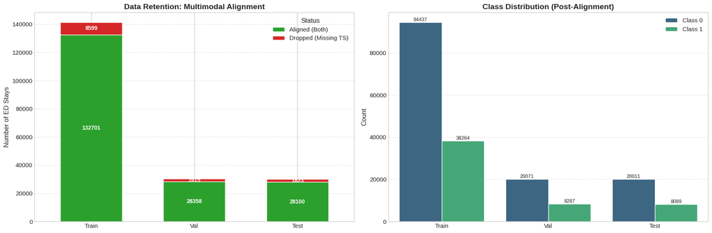

```
 Saved: /content/medfusion_work/fusion_outputs/plots/01_data_alignment.png
 File exists: True
```

```python
print("\n" + "="*60)
print("VISUALIZATION: DATA ALIGNMENT")
print("="*60)

# ENSURE OUTPUT DIRECTORIES EXIST
from pathlib import Path

# Make sure directories are created
PLOTS_DIR = Path(WORK_DIR) / "fusion_outputs" / "plots"
PLOTS_DIR.mkdir(parents=True, exist_ok=True)

print(f"✓ Output directory verified: {PLOTS_DIR}")

# Compute alignment statistics
def get_alignment_stats():
    """Calculate data retention across splits."""
    stats = []

    for split, text_path in [("Train", text_train_path),
                              ("Val", text_val_path),
                              ("Test", text_test_path)]:
        text_data = np.load(text_path)
        orig_text = len(text_data["stay_ids"])

        if split == "Train":
            aligned = len(ytr)
        elif split == "Val":
            aligned = len(yv)
        else:
            aligned = len(ys)

        dropped = orig_text - aligned

        stats.append({
            'Split': split,
            'Original (Text)': orig_text,
            'Aligned (Both)': aligned,
            'Dropped (Missing TS)': dropped,
            'Retention %': 100 * aligned / orig_text
        })

    return pd.DataFrame(stats)

stats_df = get_alignment_stats()
print("\n" + stats_df.to_string(index=False))

# Create visualization
fig, axes = plt.subplots(1, 2, figsize=(18, 6))

# Plot 1: Stacked Bar - Kept vs Dropped
ax1 = axes[0]
stats_df.set_index('Split')[['Aligned (Both)', 'Dropped (Missing TS)']].plot(
    kind='bar', stacked=True,
    color=['#2ca02c', '#d62728'],
    ax=ax1, width=0.6
)
ax1.set_title('Data Retention: Multimodal Alignment',
              fontsize=14, fontweight='bold')
ax1.set_ylabel('Number of ED Stays', fontsize=12)
ax1.set_xlabel('')
ax1.legend(title='Status', fontsize=11)
ax1.grid(axis='y', linestyle='--', alpha=0.5)
ax1.set_xticklabels(stats_df['Split'], rotation=0)

# Add percentage labels
for container in ax1.containers:
    ax1.bar_label(container, label_type='center',
                  color='white', fontweight='bold', fontsize=10)

# Plot 2: Class Distribution
ax2 = axes[1]
class_data = []
for split, y_data in [('Train', ytr), ('Val', yv), ('Test', ys)]:
    unique, counts = np.unique(y_data, return_counts=True)
    for label, count in zip(unique, counts):
        class_data.append({
            'Split': split,
            'Label': f'Class {int(label)}',
            'Count': count
        })

class_df = pd.DataFrame(class_data)
sns.barplot(data=class_df, x='Split', y='Count', hue='Label',
            palette='viridis', ax=ax2)
ax2.set_title('Class Distribution (Post-Alignment)',
              fontsize=14, fontweight='bold')
ax2.set_ylabel('Count', fontsize=12)
ax2.set_xlabel('')
ax2.legend(title='', fontsize=11)
ax2.grid(axis='y', linestyle='--', alpha=0.5)

for container in ax2.containers:
    ax2.bar_label(container, fontsize=9)

plt.tight_layout()

# Save with proper path handling
output_path = PLOTS_DIR / "01_data_alignment.png"
plt.savefig(output_path, dpi=150, bbox_inches='tight')
plt.show()

print(f"\n Saved: {output_path}")
print(f" File exists: {output_path.exists()}")
```

- 4. Dataset and DataLoaders
- 4.1. PyTorch Dataset Class

```python
print("\n" + "="*60)
print("STEP 3: CREATING PYTORCH DATASETS")
print("="*60)

class FusionDataset(Dataset):
    """
    PyTorch Dataset for multimodal fusion.

    Combines text embeddings and time-series features for each ED stay.
    """
    def __init__(self, text_emb, time_feat, labels):
        assert len(text_emb) == len(time_feat) == len(labels), \
            "All inputs must have same length"

        self.text_emb = torch.tensor(text_emb, dtype=torch.float32)
        self.time_feat = torch.tensor(time_feat, dtype=torch.float32)
        self.labels = torch.tensor(labels, dtype=torch.float32)

    def __len__(self):
        return len(self.labels)

    def __getitem__(self, idx):
        return {
            "text": self.text_emb[idx],
            "time": self.time_feat[idx],
            "label": self.labels[idx],
        }

print(" Dataset class defined")
```

```
============================================================
STEP 3: CREATING PYTORCH DATASETS
============================================================
 Dataset class defined
```

- 4.2. Create Datasets

```python
train_ds = FusionDataset(Xtr_text, Xtr_time, ytr)
val_ds = FusionDataset(Xv_text, Xv_time, yv)
test_ds = FusionDataset(Xs_text, Xs_time, ys)

print(f"\n Train dataset: {len(train_ds):,} samples")
print(f" Val dataset: {len(val_ds):,} samples")
print(f" Test dataset: {len(test_ds):,} samples")
```

```
 Train dataset: 132,701 samples
 Val dataset: 28,358 samples
 Test dataset: 28,100 samples
```

- 4.3. Create DataLoaders

```python
train_loader = DataLoader(train_ds, batch_size=BATCH_SIZE, shuffle=True, drop_last=False)
val_loader = DataLoader(val_ds, batch_size=BATCH_SIZE, shuffle=False, drop_last=False)
test_loader = DataLoader(test_ds, batch_size=BATCH_SIZE, shuffle=False, drop_last=False)

print(f"\n Train loader: {len(train_loader)} batches")
print(f" Val loader: {len(val_loader)} batches")
print(f" Test loader: {len(test_loader)} batches")
```

```
 Train loader: 1037 batches
 Val loader: 222 batches
 Test loader: 220 batches
```

- 4.4. Sanity Check DataLoaders

```python
def inspect_loader(loader, name, n_batches=5):
    """Inspect label distribution in first few batches."""
    print(f"\n--- {name} DataLoader Inspection ---")
    ys = []
    for i, batch in enumerate(loader):
        ys.append(batch["label"].detach().cpu())
        if i >= n_batches - 1:
            break
    ys = torch.cat(ys)
    counts = Counter(ys.tolist())
    total = sum(counts.values())

    print(f"  Batches inspected: {min(n_batches, len(loader))}")
    print(f"  Class 0: {counts[0.0]:,} ({100*counts[0.0]/total:.1f}%)")
    print(f"  Class 1: {counts[1.0]:,} ({100*counts[1.0]/total:.1f}%)")

inspect_loader(train_loader, "TRAIN")
inspect_loader(val_loader, "VAL")
inspect_loader(test_loader, "TEST")

print("\n✓ DataLoader verification complete")
```

```
--- TRAIN DataLoader Inspection ---
  Batches inspected: 5
  Class 0: 460 (71.9%)
  Class 1: 180 (28.1%)

--- VAL DataLoader Inspection ---
  Batches inspected: 5
  Class 0: 449 (70.2%)
  Class 1: 191 (29.8%)

--- TEST DataLoader Inspection ---
  Batches inspected: 5
  Class 0: 454 (70.9%)
  Class 1: 186 (29.1%)

✓ DataLoader verification complete
```

- 5. Model Architecture
- 5.1. Text Encoder

```python
print("\n" + "="*60)
print("STEP 4: DEFINING MODEL ARCHITECTURES")
print("="*60)

class TextHead(nn.Module):
    """
    Text modality encoder.

    Maps BiLSTM embeddings (256-dim) → hidden representation → logit
    """
    def __init__(self, in_dim, hidden_dim=256, dropout=0.3):
        super().__init__()
        self.net = nn.Sequential(
            nn.Linear(in_dim, hidden_dim),
            nn.BatchNorm1d(hidden_dim),
            nn.ReLU(),
            nn.Dropout(dropout),
            nn.Linear(hidden_dim, hidden_dim),
            nn.BatchNorm1d(hidden_dim),
            nn.ReLU(),
            nn.Dropout(dropout),
        )
        self.out = nn.Linear(hidden_dim, 1)

    def forward(self, x):
        h = self.net(x)
        return self.out(h).squeeze(-1)

print(" TextHead defined")
```

```
============================================================
STEP 4: DEFINING MODEL ARCHITECTURES
============================================================
 TextHead defined
```

- 5.2. Time-Series Encoder

```python
class TimeHead(nn.Module):
    """
    Time-series modality encoder.

    Maps transformer features (66-dim) → hidden representation → logit
    """
    def __init__(self, in_dim, hidden_dim=256, dropout=0.3):
        super().__init__()
        self.net = nn.Sequential(
            nn.Linear(in_dim, hidden_dim),
            nn.BatchNorm1d(hidden_dim),
            nn.ReLU(),
            nn.Dropout(dropout),
            nn.Linear(hidden_dim, hidden_dim),
            nn.BatchNorm1d(hidden_dim),
            nn.ReLU(),
            nn.Dropout(dropout),
        )
        self.out = nn.Linear(hidden_dim, 1)

    def forward(self, x):
        h = self.net(x)
        return self.out(h).squeeze(-1)

print(" TimeHead defined")
```

```
 TimeHead defined
```

- 5.3. Late Fusion Model

```python
class FusionLateModel(nn.Module):
    """
    Late fusion architecture for multimodal classification.

    Strategy:
    ---------
    1. Each modality processed by separate encoder
    2. Each encoder outputs a logit
    3. Learnable weight α combines logits:
         y_fused = α * logit_text + (1-α) * logit_time

    This allows the model to learn optimal modality weighting.
    """
    def __init__(self, text_dim, time_dim, hidden_dim=256, dropout=0.3):
        super().__init__()
        self.text_head = TextHead(text_dim, hidden_dim, dropout)
        self.time_head = TimeHead(time_dim, hidden_dim, dropout)

        # Learnable fusion weight (initialized at 0.5 = equal weighting)
        self.alpha = nn.Parameter(torch.tensor(0.5))

    def forward(self, text_x, time_x, mode="fusion"):
        """
        Forward pass with mode selection.

        Parameters:
        -----------
        mode : str
            - "text": Use only text modality
            - "time": Use only time modality
            - "fusion": Use both modalities with learned weighting
        """
        logit_text = self.text_head(text_x)
        logit_time = self.time_head(time_x)

        if mode == "text":
            return logit_text
        elif mode == "time":
            return logit_time
        else:  # "fusion"
            w = torch.sigmoid(self.alpha)  # Ensures w ∈ [0,1]
            return w * logit_text + (1.0 - w) * logit_time

print(" FusionLateModel defined")
print("\n All model architectures ready")
```

```
 FusionLateModel defined

 All model architectures ready
```

- 6. Training Infrastructure
- 6.1. Compute Class Weights

```python
print("\n" + "="*60)
print("STEP 5: COMPUTING CLASS WEIGHTS")
print("="*60)

# Extract all labels from training set
all_train_labels = []
for batch in train_loader:
    all_train_labels.append(batch["label"].numpy())
all_train_labels = np.concatenate(all_train_labels)

# Count classes
neg = (all_train_labels == 0).sum()
pos = (all_train_labels == 1).sum()
pos_weight_value = neg / (pos + 1e-8)

print(f"\nClass distribution in training set:")
print(f"  Negative (y=0): {neg:,} ({100*neg/(neg+pos):.1f}%)")
print(f"  Positive (y=1): {pos:,} ({100*pos/(neg+pos):.1f}%)")
print(f"  Imbalance ratio: {neg/pos:.2f}:1")
print(f"\n Computed pos_weight: {pos_weight_value:.2f}")
print("  (Will be used in BCE loss to handle class imbalance)")
```

```
============================================================
STEP 5: COMPUTING CLASS WEIGHTS
============================================================

Class distribution in training set:
  Negative (y=0): 94,437 (71.2%)
  Positive (y=1): 38,264 (28.8%)
  Imbalance ratio: 2.47:1

 Computed pos_weight: 2.47
  (Will be used in BCE loss to handle class imbalance)
```

- 6.2. Metrics Function

```python
def binary_metrics(y_true, y_prob, threshold=0.5):
    """
    Compute comprehensive binary classification metrics.

    Returns:
    --------
    dict with keys:
        - auc: Area Under ROC Curve
        - f1: F1-score
        - precision: Positive Predictive Value
        - recall: Sensitivity / True Positive Rate
        - specificity: True Negative Rate
        - accuracy: Overall accuracy
        - confusion: (TN, FP, FN, TP) tuple
    """
    y_true = np.asarray(y_true).astype(int)
    y_prob = np.asarray(y_prob)
    y_pred = (y_prob >= threshold).astype(int)

    auc_score = roc_auc_score(y_true, y_prob)
    f1 = f1_score(y_true, y_pred, zero_division=0)
    prec = precision_score(y_true, y_pred, zero_division=0)
    rec = recall_score(y_true, y_pred, zero_division=0)
    acc = accuracy_score(y_true, y_pred)

    tn, fp, fn, tp = confusion_matrix(y_true, y_pred).ravel()
    spec = tn / (tn + fp + 1e-8)

    return {
        "auc": auc_score,
        "f1": f1,
        "precision": prec,
        "recall": rec,
        "accuracy": acc,
        "specificity": spec,
        "confusion": (tn, fp, fn, tp),
    }

print(" Metrics function defined")
```

```
 Metrics function defined
```

- 6.3. Plotting Functions

```python
def plot_training_curves(history, model_name):
    """Plot training/validation loss and validation AUC."""
    epochs = range(1, len(history["train_loss"]) + 1)

    fig, axes = plt.subplots(1, 2, figsize=(14, 5))

    # Loss curves
    ax1 = axes[0]
    ax1.plot(epochs, history["train_loss"], label="Train Loss",
             marker='o', linewidth=2)
    ax1.plot(epochs, history["val_loss"], label="Val Loss",
             marker='s', linewidth=2)
    ax1.set_xlabel("Epoch", fontsize=12)
    ax1.set_ylabel("Binary Cross-Entropy Loss", fontsize=12)
    ax1.set_title(f"{model_name} – Training Curves",
                  fontsize=14, fontweight='bold')
    ax1.legend(fontsize=11)
    ax1.grid(True, alpha=0.3)

    # AUC curve
    ax2 = axes[1]
    ax2.plot(epochs, history["val_auc"], marker="o",
             linewidth=2, color='green')
    ax2.set_xlabel("Epoch", fontsize=12)
    ax2.set_ylabel("Validation AUC", fontsize=12)
    ax2.set_title(f"{model_name} – Validation Performance",
                  fontsize=14, fontweight='bold')
    ax2.grid(True, alpha=0.3)
    ax2.set_ylim([0.45, 1.0])

    plt.tight_layout()
    path = PLOTS_DIR / f"{model_name}_training.png"
    plt.savefig(path, dpi=150, bbox_inches='tight')
    plt.show()

    print(f" Saved training curves: {path}")

def plot_confusion_matrix(cm, model_name):
    """Plot confusion matrix heatmap."""
    tn, fp, fn, tp = cm
    mat = np.array([[tn, fp], [fn, tp]])

    plt.figure(figsize=(6, 5))
    sns.heatmap(mat, annot=True, fmt="d", cmap="Blues",
                xticklabels=["Predicted 0", "Predicted 1"],
                yticklabels=["True 0", "True 1"],
                cbar_kws={'label': 'Count'})
    plt.title(f"{model_name} – Confusion Matrix",
              fontsize=14, fontweight='bold')
    plt.ylabel("True Label", fontsize=12)
    plt.xlabel("Predicted Label", fontsize=12)
    plt.tight_layout()

    path = PLOTS_DIR / f"{model_name}_confusion.png"
    plt.savefig(path, dpi=150, bbox_inches='tight')
    plt.show()

    print(f" Saved confusion matrix: {path}")

print(" Plotting functions defined")
```

```
 Plotting functions defined
```

- 7. Training and Evaluation Functions
- 7.1. Training Function

```python
def train_model(model, train_loader, val_loader,
                mode="fusion", n_epochs=20,
                lr=1e-3, weight_decay=1e-4,
                patience=5, model_name="Fusion"):
    """
    Train a FusionLateModel with early stopping.

    Parameters:
    -----------
    mode : str
        Which modality/fusion strategy to use ("text", "time", or "fusion")

    Returns:
    --------
    model : trained model
    history : dict with training curves
    best_auc : float, best validation AUC achieved
    """
    model = model.to(device)

    # Class-weighted loss
    pos_weight = torch.tensor(pos_weight_value, dtype=torch.float32, device=device)
    criterion = nn.BCEWithLogitsLoss(pos_weight=pos_weight)

    # Optimizer
    optimizer = torch.optim.AdamW(model.parameters(), lr=lr, weight_decay=weight_decay)

    # Training state
    history = {"train_loss": [], "val_loss": [], "val_auc": []}
    best_state = None
    best_auc = 0.0
    no_improve = 0

    print(f"\n{'='*60}")
    print(f"Training {model_name} ({mode} mode)")
    print(f"{'='*60}")

    for epoch in range(1, n_epochs + 1):
        # TRAINING PHASE
        model.train()
        running_loss = 0.0

        for batch in train_loader:
            text_x = batch["text"].to(device)
            time_x = batch["time"].to(device)
            labels = batch["label"].to(device)

            optimizer.zero_grad()
            logits = model(text_x, time_x, mode=mode)
            loss = criterion(logits, labels)
            loss.backward()
            optimizer.step()

            running_loss += loss.item() * labels.size(0)

        train_loss = running_loss / len(train_loader.dataset)

        # VALIDATION PHASE
        model.eval()
        val_loss = 0.0
        all_probs, all_labels = [], []

        with torch.no_grad():
            for batch in val_loader:
                text_x = batch["text"].to(device)
                time_x = batch["time"].to(device)
                labels = batch["label"].to(device)

                logits = model(text_x, time_x, mode=mode)
                loss = criterion(logits, labels)
                val_loss += loss.item() * labels.size(0)

                probs = torch.sigmoid(logits).cpu().numpy()
                all_probs.append(probs)
                all_labels.append(labels.cpu().numpy())

        val_loss = val_loss / len(val_loader.dataset)
        all_probs = np.concatenate(all_probs)
        all_labels = np.concatenate(all_labels)

        metrics = binary_metrics(all_labels, all_probs)
        val_auc = metrics["auc"]

        # Record history
        history["train_loss"].append(train_loss)
        history["val_loss"].append(val_loss)
        history["val_auc"].append(val_auc)

        # Print progress
        print(f"  Epoch {epoch:02d}/{n_epochs} | "
              f"Train Loss: {train_loss:.4f} | "
              f"Val Loss: {val_loss:.4f} | "
              f"Val AUC: {val_auc:.4f}")

        # Early stopping check
        if val_auc > best_auc + 1e-4:
            best_auc = val_auc
            best_state = model.state_dict()
            no_improve = 0
        else:
            no_improve += 1
            if no_improve >= patience:
                print(f"\n  ⚠ Early stopping triggered (patience={patience})")
                break

    # Restore best model
    if best_state is not None:
        model.load_state_dict(best_state)
        print(f"\n✓ Restored best model (Val AUC: {best_auc:.4f})")

    # Plot training curves
    plot_training_curves(history, model_name=f"{model_name}_{mode}")

    return model, history, best_auc

print(" Training function defined")
```

```
 Training function defined
```

- 7.2. Evaluation Function

```python
def evaluate_model(model, loader, mode="fusion", model_name="Fusion"):
    """
    Evaluate a trained model on a dataset.

    Returns:
    --------
    y_true : np.ndarray
        True labels
    y_prob : np.ndarray
        Predicted probabilities
    metrics : dict
        Performance metrics
    """
    model = model.to(device)
    model.eval()

    all_probs, all_labels = [], []

    with torch.no_grad():
        for batch in loader:
            text_x = batch["text"].to(device)
            time_x = batch["time"].to(device)
            labels = batch["label"].cpu().numpy()

            logits = model(text_x, time_x, mode=mode)
            probs = torch.sigmoid(logits).cpu().numpy()

            all_probs.append(probs)
            all_labels.append(labels)

    y_prob = np.concatenate(all_probs)
    y_true = np.concatenate(all_labels)

    metrics = binary_metrics(y_true, y_prob)

    # Print metrics
    print(f"\n{'='*60}")
    print(f"{model_name} ({mode}) – TEST SET RESULTS")
    print(f"{'='*60}")
    print(f"  AUC:         {metrics['auc']:.4f}")
    print(f"  F1-Score:    {metrics['f1']:.4f}")
    print(f"  Precision:   {metrics['precision']:.4f}")
    print(f"  Recall:      {metrics['recall']:.4f}")
    print(f"  Specificity: {metrics['specificity']:.4f}")
    print(f"  Accuracy:    {metrics['accuracy']:.4f}")

    tn, fp, fn, tp = metrics["confusion"]
    print(f"\n  Confusion Matrix:")
    print(f"    TN={tn:,}  FP={fp:,}")
    print(f"    FN={fn:,}  TP={tp:,}")

    # Plot confusion matrix
    plot_confusion_matrix(metrics["confusion"],
                          model_name=f"{model_name}_{mode}")

    return y_true, y_prob, metrics

print(" Evaluation function defined")
```

```
 Evaluation function defined
```

- 8. Train All Models
- 8.1. Text-Only Baseline

```
============================================================
EXPERIMENT 1: TEXT-ONLY MODEL
============================================================

============================================================
Training Text_Only (text mode)
============================================================

  ⚠ Early stopping triggered (patience=5)

✓ Restored best model (Val AUC: 0.8195)
```

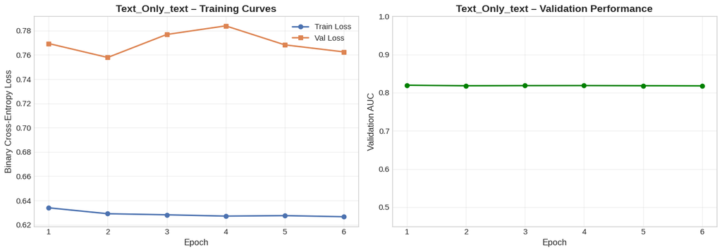

```
 Saved training curves: /content/medfusion_work/fusion_outputs/plots/Text_Only_text_training.png

============================================================
Text_Only (text) – TEST SET RESULTS
============================================================
  AUC:         0.8112
  F1-Score:    0.6078
  Precision:   0.5311
  Recall:      0.7103
  Specificity: 0.7464
  Accuracy:    0.7360

  Confusion Matrix:
    TN=14,937  FP=5,074
    FN=2,343  TP=5,746
```

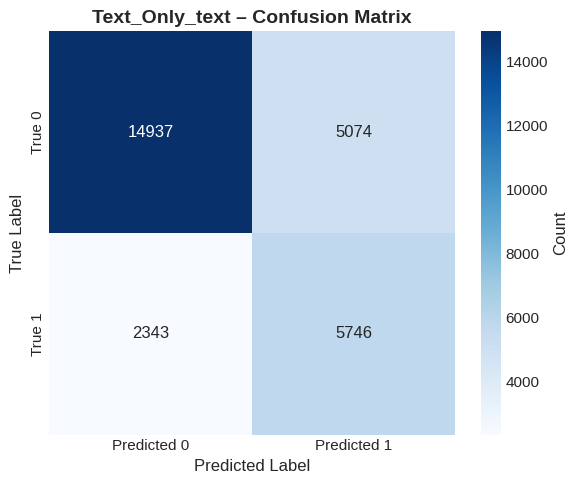

```
 Saved confusion matrix: /content/medfusion_work/fusion_outputs/plots/Text_Only_text_confusion.png
```

```python
print("\n" + "="*60)
print("EXPERIMENT 1: TEXT-ONLY MODEL")
print("="*60)

clear_gpu()
text_model = FusionLateModel(text_dim, time_dim,
                              hidden_dim=HIDDEN_DIM, dropout=DROPOUT)

text_model, hist_text, val_auc_text = train_model(
    text_model, train_loader, val_loader,
    mode="text", n_epochs=N_EPOCHS, lr=LEARNING_RATE,
    weight_decay=WEIGHT_DECAY, patience=PATIENCE,
    model_name="Text_Only"
)

y_text_test, p_text_test, metrics_text = evaluate_model(
    text_model, test_loader, mode="text",
    model_name="Text_Only"
)
```

- 8.2. Time-Only Baseline

```
============================================================
EXPERIMENT 2: TIME-ONLY MODEL
============================================================

============================================================
Training Time_Only (time mode)
============================================================

✓ Restored best model (Val AUC: 0.7599)
```

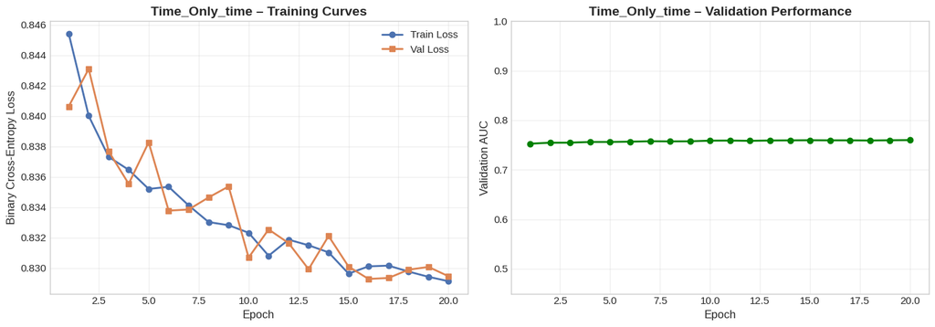

```
 Saved training curves: /content/medfusion_work/fusion_outputs/plots/Time_Only_time_training.png

============================================================
Time_Only (time) – TEST SET RESULTS
============================================================
  AUC:         0.7501
  F1-Score:    0.5567
  Precision:   0.4555
  Recall:      0.7157
  Specificity: 0.6541
  Accuracy:    0.6719

  Confusion Matrix:
    TN=13,090  FP=6,921
    FN=2,300  TP=5,789
```

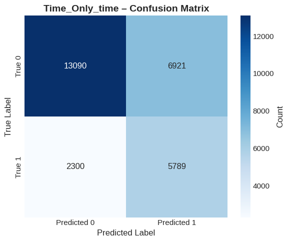

```
 Saved confusion matrix: /content/medfusion_work/fusion_outputs/plots/Time_Only_time_confusion.png
```

```python
print("\n" + "="*60)
print("EXPERIMENT 2: TIME-ONLY MODEL")
print("="*60)

clear_gpu()
time_model = FusionLateModel(text_dim, time_dim,
                              hidden_dim=HIDDEN_DIM, dropout=DROPOUT)

time_model, hist_time, val_auc_time = train_model(
    time_model, train_loader, val_loader,
    mode="time", n_epochs=N_EPOCHS, lr=LEARNING_RATE,
    weight_decay=WEIGHT_DECAY, patience=PATIENCE,
    model_name="Time_Only"
)

y_time_test, p_time_test, metrics_time = evaluate_model(
    time_model, test_loader, mode="time",
    model_name="Time_Only"
)
```

## 8.3. Multimodal Fusion

```
============================================================
EXPERIMENT 3: MULTIMODAL FUSION
============================================================

============================================================
Training Multimodal_Fusion (fusion mode)
============================================================

  ⚠ Early stopping triggered (patience=5)

✓ Restored best model (Val AUC: 0.8416)
```

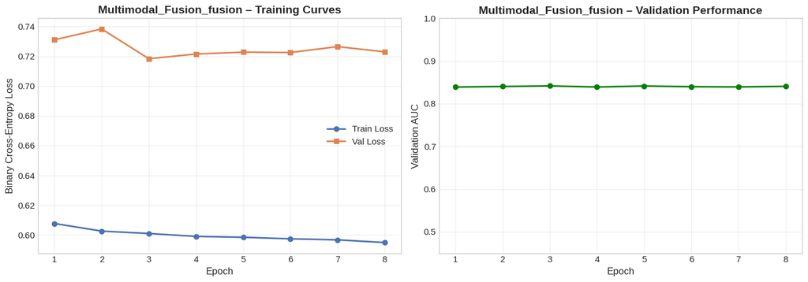

```
 Saved training curves: /content/medfusion_work/fusion_outputs/plots/Multimodal_Fusion_fusion_training.png

============================================================
Multimodal_Fusion (fusion) – TEST SET RESULTS
============================================================
  AUC:         0.8346
  F1-Score:    0.6374
  Precision:   0.5594
  Recall:      0.7405
  Specificity: 0.7643
  Accuracy:    0.7574

  Confusion Matrix:
    TN=15,294  FP=4,717
    FN=2,099  TP=5,990
```

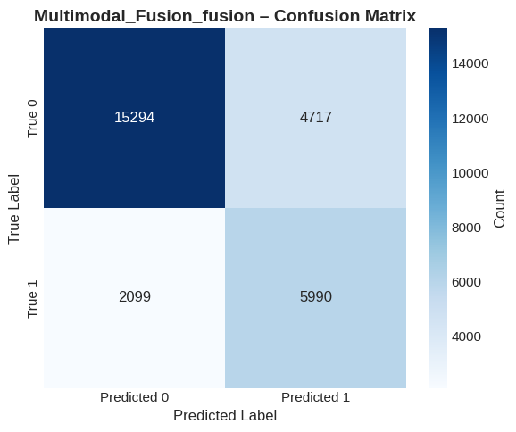

```
 Saved confusion matrix: /content/medfusion_work/fusion_outputs/plots/Multimodal_Fusion_fusion_confusion.png

✓ Learned fusion weight α = 0.634
  Text contribution: 63.4%
  Time contribution: 36.6%
```

```python
print("\n" + "="*60)
print("EXPERIMENT 3: MULTIMODAL FUSION")
print("="*60)

clear_gpu()
fusion_model = FusionLateModel(text_dim, time_dim,
                                hidden_dim=HIDDEN_DIM, dropout=DROPOUT)

fusion_model, hist_fusion, val_auc_fusion = train_model(
    fusion_model, train_loader, val_loader,
    mode="fusion", n_epochs=N_EPOCHS, lr=LEARNING_RATE,
    weight_decay=WEIGHT_DECAY, patience=PATIENCE,
    model_name="Multimodal_Fusion"
)

y_fusion_test, p_fusion_test, metrics_fusion = evaluate_model(
    fusion_model, test_loader, mode="fusion",
    model_name="Multimodal_Fusion"
)

# Inspect learned fusion weight
with torch.no_grad():
    alpha_val = torch.sigmoid(fusion_model.alpha).item()
print(f"\n✓ Learned fusion weight α = {alpha_val:.3f}")
print(f"  Text contribution: {alpha_val:.1%}")
print(f"  Time contribution: {(1-alpha_val):.1%}")
```

- 9. Comparative Analysis
- 9.1. Performance Summary Table

```python
print("\n" + "="*60)
print("SUMMARY: MODEL COMPARISON")
print("="*60)

summary_data = {
    'Model': ['Text-Only', 'Time-Only', 'Multimodal Fusion'],
    'Val AUC': [val_auc_text, val_auc_time, val_auc_fusion],
    'Test AUC': [metrics_text['auc'], metrics_time['auc'], metrics_fusion['auc']],
    'F1-Score': [metrics_text['f1'], metrics_time['f1'], metrics_fusion['f1']],
    'Precision': [metrics_text['precision'], metrics_time['precision'], metrics_fusion['precision']],
    'Recall': [metrics_text['recall'], metrics_time['recall'], metrics_fusion['recall']],
    'Specificity': [metrics_text['specificity'], metrics_time['specificity'], metrics_fusion['specificity']],
}

summary_df = pd.DataFrame(summary_data)
print("\n" + summary_df.to_string(index=False))

# Highlight best model
best_model_idx = summary_df['Test AUC'].idxmax()
best_model = summary_df.loc[best_model_idx, 'Model']
best_auc = summary_df.loc[best_model_idx, 'Test AUC']

print(f"\n BEST MODEL: {best_model} (Test AUC = {best_auc:.4f})")
```

```
============================================================
SUMMARY: MODEL COMPARISON
============================================================

            Model  Val AUC  Test AUC  F1-Score  Precision   Recall  Specificity
        Text-Only 0.819549  0.811231  0.607753   0.531054 0.710347     0.746439
        Time-Only 0.759927  0.750106  0.556661   0.455468 0.715663     0.654140
Multimodal Fusion 0.841610  0.834551  0.637370   0.559447 0.740512     0.764280

✓ BEST MODEL: Multimodal Fusion (Test AUC = 0.8346)
```

- 9.2. ROC Curve Comparison

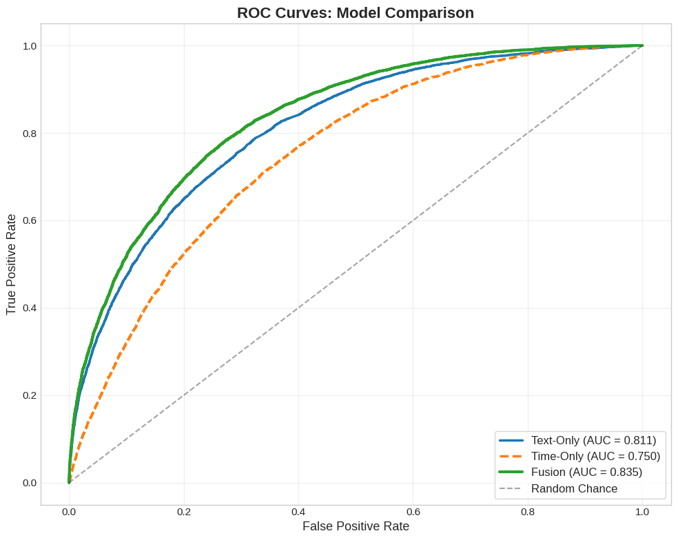

```
 Saved ROC comparison: /content/medfusion_work/fusion_outputs/plots/02_roc_comparison.png
```

```python
fig, ax = plt.subplots(figsize=(10, 8))

# Text-only ROC
fpr_text, tpr_text, _ = roc_curve(y_text_test, p_text_test)
ax.plot(fpr_text, tpr_text,
        label=f'Text-Only (AUC = {metrics_text["auc"]:.3f})',
        color='#1f77b4', linewidth=2.5)

# Time-only ROC
fpr_time, tpr_time, _ = roc_curve(y_time_test, p_time_test)
ax.plot(fpr_time, tpr_time,
        label=f'Time-Only (AUC = {metrics_time["auc"]:.3f})',
        color='#ff7f0e', linewidth=2.5, linestyle='--')

# Fusion ROC
fpr_fusion, tpr_fusion, _ = roc_curve(y_fusion_test, p_fusion_test)
ax.plot(fpr_fusion, tpr_fusion,
        label=f'Fusion (AUC = {metrics_fusion["auc"]:.3f})',
        color='#2ca02c', linewidth=3)

# Random baseline
ax.plot([0, 1], [0, 1], 'k--', alpha=0.4, label='Random Chance')

ax.set_xlabel('False Positive Rate', fontsize=13)
ax.set_ylabel('True Positive Rate', fontsize=13)
ax.set_title('ROC Curves: Model Comparison', fontsize=16, fontweight='bold')
ax.legend(loc="lower right", fontsize=12, frameon=True)
ax.grid(True, alpha=0.3)

plt.tight_layout()
plt.savefig(PLOTS_DIR / "02_roc_comparison.png", dpi=150, bbox_inches='tight')
plt.show()

print(f" Saved ROC comparison: {PLOTS_DIR / '02_roc_comparison.png'}")
```

- 9.3. Confusion Matrix Comparison

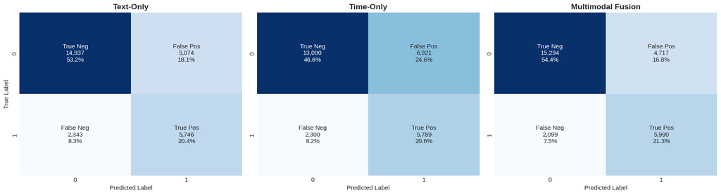

```
✓ Saved confusion comparison: /content/medfusion_work/fusion_outputs/plots/03_confusion_comparison.png
```

```python
fig, axes = plt.subplots(1, 3, figsize=(18, 5))

for idx, (cm, name, ax) in enumerate([
    (metrics_text['confusion'], 'Text-Only', axes[0]),
    (metrics_time['confusion'], 'Time-Only', axes[1]),
    (metrics_fusion['confusion'], 'Multimodal Fusion', axes[2])
]):
    tn, fp, fn, tp = cm
    mat = np.array([[tn, fp], [fn, tp]])

    # Create labels with counts and percentages
    group_names = ['True Neg', 'False Pos', 'False Neg', 'True Pos']
    group_counts = [f"{value:,}" for value in mat.flatten()]
    group_percentages = [f"{value:.1%}" for value in mat.flatten()/np.sum(mat)]
    labels = [f"{v1}\n{v2}\n{v3}" for v1, v2, v3 in
              zip(group_names, group_counts, group_percentages)]
    labels = np.asarray(labels).reshape(2, 2)

    sns.heatmap(mat, annot=labels, fmt='', cmap='Blues', ax=ax,
                cbar=False, annot_kws={"size": 11})
    ax.set_title(name, fontsize=14, fontweight='bold')
    ax.set_xlabel('Predicted Label', fontsize=11)
    ax.set_ylabel('True Label' if idx == 0 else '', fontsize=11)

plt.tight_layout()
plt.savefig(PLOTS_DIR / "03_confusion_comparison.png", dpi=150, bbox_inches='tight')
plt.show()

print(f"✓ Saved confusion comparison: {PLOTS_DIR / '03_confusion_comparison.png'}")
```

- 10. Calibration Analysis
- 10.1. Temperature Scaling

```python
print("\n" + "="*60)
print("STEP 6: PROBABILITY CALIBRATION")
print("="*60)

class TemperatureScaler(nn.Module):
    """Post-hoc calibration via temperature scaling."""
    def __init__(self):
        super().__init__()
        self.log_T = nn.Parameter(torch.zeros(1))

    def forward(self, logits):
        T = torch.exp(self.log_T)
        return logits / T

def fit_temperature(model, val_loader, mode="fusion"):
    """
    Fit temperature parameter on validation set.

    Minimizes negative log-likelihood to find optimal T that
    makes predicted probabilities match observed frequencies.
    """
    model.eval()
    logits_list, labels_list = [], []

    print(f"Collecting validation logits...")
    with torch.no_grad():
        for batch in val_loader:
            text_x = batch["text"].to(device)
            time_x = batch["time"].to(device)
            labels = batch["label"].float().to(device)

            logits = model(text_x, time_x, mode=mode)
            if logits.ndim > 1:
                logits = logits.squeeze(-1)

            logits_list.append(logits)
            labels_list.append(labels)

    logits = torch.cat(logits_list)
    labels = torch.cat(labels_list)

    # Optimize temperature
    scaler = TemperatureScaler().to(device)
    optimizer = torch.optim.LBFGS([scaler.log_T], lr=0.01, max_iter=50)
    criterion = nn.BCEWithLogitsLoss()

    def _closure():
        optimizer.zero_grad()
        scaled_logits = scaler(logits)
        loss = criterion(scaled_logits, labels)
        loss.backward()
        return loss

    optimizer.step(_closure)

    T = torch.exp(scaler.log_T).item()
    print(f"✓ Optimal temperature: T = {T:.3f}")

    return scaler

# Apply to best model (fusion)
clear_gpu()
temp_scaler = fit_temperature(fusion_model, val_loader, mode="fusion")
```

```
============================================================
STEP 6: PROBABILITY CALIBRATION
============================================================
✓ Optimal temperature: T = 1.106
```

- 10.2. Apply Calibration to Test Set

```python
print("\nApplying calibration to test set...")

fusion_model.eval()
logits_uncal, logits_cal, labels_test = [], [], []

with torch.no_grad():
    for batch in test_loader:
        text_x = batch["text"].to(device)
        time_x = batch["time"].to(device)
        labels = batch["label"].cpu().numpy()

        logits = fusion_model(text_x, time_x, mode="fusion")
        if logits.ndim > 1:
            logits = logits.squeeze(-1)

        logits_uncal.append(logits.cpu().numpy())
        logits_cal.append(temp_scaler(logits).cpu().numpy())
        labels_test.append(labels)

logits_uncal = np.concatenate(logits_uncal)
logits_cal = np.concatenate(logits_cal)
labels_test = np.concatenate(labels_test)

# Convert to probabilities
probs_uncal = 1 / (1 + np.exp(-logits_uncal))
probs_cal = 1 / (1 + np.exp(-logits_cal))

# Compute metrics
metrics_uncal = binary_metrics(labels_test, probs_uncal)
metrics_cal = binary_metrics(labels_test, probs_cal)

print(f"\n{'='*60}")
print("CALIBRATION COMPARISON (Test Set)")
print(f"{'='*60}")
print(f"                  Uncalibrated    Calibrated")
print(f"  AUC:            {metrics_uncal['auc']:.4f}          {metrics_cal['auc']:.4f}")
print(f"  F1-Score:       {metrics_uncal['f1']:.4f}          {metrics_cal['f1']:.4f}")
print(f"  Precision:      {metrics_uncal['precision']:.4f}          {metrics_cal['precision']:.4f}")
print(f"  Recall:         {metrics_uncal['recall']:.4f}          {metrics_cal['recall']:.4f}")

print("\n Calibration preserves discrimination (AUC) while improving reliability")
```

[output not shown]

- 10.3. Reliability Diagrams

```
✓ Calibration directory created: /content/medfusion_work/fusion_outputs/calibration
```

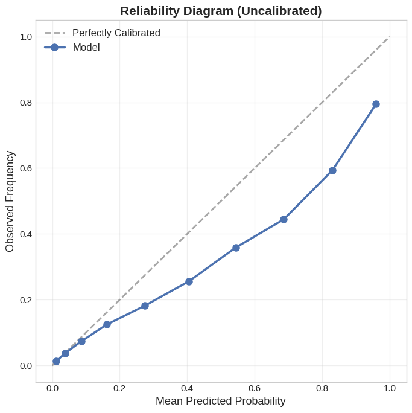

```
✓ Saved: /content/medfusion_work/fusion_outputs/calibration/reliability_uncalibrated.png
```

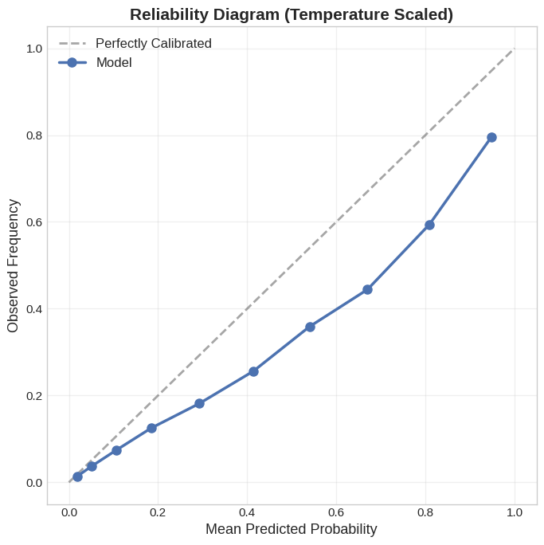

```
✓ Saved: /content/medfusion_work/fusion_outputs/calibration/reliability_calibrated.png
```

```python
# ============================================================
# FIX: Create calibration directory before plotting
# ============================================================

from pathlib import Path

# Ensure CALIB_DIR exists
CALIB_DIR = Path(WORK_DIR) / "fusion_outputs" / "calibration"
CALIB_DIR.mkdir(parents=True, exist_ok=True)
print(f"✓ Calibration directory created: {CALIB_DIR}")

# Now run the reliability diagrams
def plot_reliability_diagram(y_true, y_probs, title, filename, bins=10):
    """
    Plot calibration curve showing predicted vs observed frequencies.

    A well-calibrated model's curve should closely follow the diagonal.
    """
    prob_true, prob_pred = calibration_curve(
        y_true, y_probs, n_bins=bins, strategy='quantile'
    )

    fig, ax = plt.subplots(figsize=(7, 7))

    # Perfect calibration line
    ax.plot([0, 1], [0, 1], linestyle='--', color='gray',
            linewidth=2, label='Perfectly Calibrated', alpha=0.7)

    # Model calibration
    ax.plot(prob_pred, prob_true, marker='o', linewidth=2.5,
            markersize=8, label='Model')

    ax.set_xlabel("Mean Predicted Probability", fontsize=13)
    ax.set_ylabel("Observed Frequency", fontsize=13)
    ax.set_title(title, fontsize=15, fontweight='bold')
    ax.legend(loc="upper left", fontsize=12)
    ax.grid(True, alpha=0.3)
    ax.set_xlim([-0.05, 1.05])
    ax.set_ylim([-0.05, 1.05])

    plt.tight_layout()
    plt.savefig(filename, dpi=150, bbox_inches='tight')
    plt.show()

    print(f"✓ Saved: {filename}")

# Plot uncalibrated
plot_reliability_diagram(
    labels_test, probs_uncal,
    title="Reliability Diagram (Uncalibrated)",
    filename=CALIB_DIR / "reliability_uncalibrated.png"
)

# Plot calibrated
plot_reliability_diagram(
    labels_test, probs_cal,
    title="Reliability Diagram (Temperature Scaled)",
    filename=CALIB_DIR / "reliability_calibrated.png"
)
```

- 11. Save Models and Results
- 11.1. Save Model Checkpoints

```python
#1.1. Save Model Checkpoints
print("\n" + "="*60)
print("SAVING MODELS AND RESULTS")
print("="*60)

# **FIX: Ensure MODEL_DIR exists**
from pathlib import Path
MODEL_DIR = Path(WORK_DIR) / "fusion_outputs" / "models"
MODEL_DIR.mkdir(parents=True, exist_ok=True)
print(f"✓ Model directory created: {MODEL_DIR}")

# Save model checkpoints
torch.save({
    'model_state_dict': text_model.state_dict(),
    'val_auc': val_auc_text,
    'test_metrics': metrics_text,
}, MODEL_DIR / "text_only_model.pth")
print(f"✓ Saved text model")

torch.save({
    'model_state_dict': time_model.state_dict(),
    'val_auc': val_auc_time,
    'test_metrics': metrics_time,
}, MODEL_DIR / "time_only_model.pth")
print(f"✓ Saved time model")

torch.save({
    'model_state_dict': fusion_model.state_dict(),
    'val_auc': val_auc_fusion,
    'test_metrics': metrics_fusion,
    'temp_scaler': temp_scaler.state_dict(),
}, MODEL_DIR / "fusion_model.pth")
print(f"✓ Saved fusion model")
```

```
============================================================
SAVING MODELS AND RESULTS
============================================================
✓ Model directory created: /content/medfusion_work/fusion_outputs/models
✓ Saved text model
✓ Saved time model
✓ Saved fusion model
```

```python
print("\n" + "="*60)
print("SAVING MODELS AND RESULTS")
print("="*60)

# Save model checkpoints
torch.save({
    'model_state_dict': text_model.state_dict(),
    'val_auc': val_auc_text,
    'test_metrics': metrics_text,
}, MODEL_DIR / "text_only_model.pth")
print(f" Saved text model")

torch.save({
    'model_state_dict': time_model.state_dict(),
    'val_auc': val_auc_time,
    'test_metrics': metrics_time,
}, MODEL_DIR / "time_only_model.pth")
print(f" Saved time model")

torch.save({
    'model_state_dict': fusion_model.state_dict(),
    'val_auc': val_auc_fusion,
    'test_metrics': metrics_fusion,
    'temp_scaler': temp_scaler.state_dict(),
}, MODEL_DIR / "fusion_model.pth")
print(f" Saved fusion model")
```

```
============================================================
SAVING MODELS AND RESULTS
============================================================
 Saved text model
 Saved time model
 Saved fusion model
```

- 12. Final Summary Report

```python
# 12. Final Summary Report


# **FIX: Define missing variables**
from pathlib import Path

# Ensure all directories are defined
PLOTS_DIR = Path(WORK_DIR) / "fusion_outputs" / "plots"
CALIB_DIR = Path(WORK_DIR) / "fusion_outputs" / "calibration"
MODEL_DIR = Path(WORK_DIR) / "fusion_outputs" / "models"
BASE_OUT_DIR = Path(WORK_DIR) / "fusion_outputs"

# Define results_path
results_path = BASE_OUT_DIR / "model_results.csv"

# Determine best model
auc_scores = {
    'Text-Only': metrics_text['auc'],
    'Time-Only': metrics_time['auc'],
    'Fusion': metrics_fusion['auc']
}
best_model = max(auc_scores, key=auc_scores.get)
best_auc = auc_scores[best_model]

print("\n" + "="*70)
print("                  FINAL REPORT: MULTIMODAL FUSION")
print("="*70)

print(f"""
DATASET SUMMARY:
  Training samples:   {len(train_ds):,}
  Validation samples: {len(val_ds):,}
  Test samples:       {len(test_ds):,}

  Text embedding dimension:       {text_dim}
  Time-series feature dimension:  {time_dim}

  Class balance (train): {100*pos/(neg+pos):.1f}% positive

MODEL ARCHITECTURES:
  Text Head:   {text_dim} → {HIDDEN_DIM} → {HIDDEN_DIM} → 1 (logit)
  Time Head:   {time_dim} → {HIDDEN_DIM} → {HIDDEN_DIM} → 1 (logit)
  Fusion:      Learnable weighting (α = {alpha_val:.3f})

PERFORMANCE COMPARISON:

  Model              Val AUC    Test AUC    F1-Score    Recall    Specificity
  -------------------------------------------------------------------------------
  Text-Only          {val_auc_text:.4f}     {metrics_text['auc']:.4f}      {metrics_text['f1']:.4f}      {metrics_text['recall']:.4f}    {metrics_text['specificity']:.4f}
  Time-Only          {val_auc_time:.4f}     {metrics_time['auc']:.4f}      {metrics_time['f1']:.4f}      {metrics_time['recall']:.4f}    {metrics_time['specificity']:.4f}
  Fusion             {val_auc_fusion:.4f}     {metrics_fusion['auc']:.4f}      {metrics_fusion['f1']:.4f}      {metrics_fusion['recall']:.4f}    {metrics_fusion['specificity']:.4f}
  Fusion (Cal.)      N/A        {metrics_cal['auc']:.4f}      {metrics_cal['f1']:.4f}      {metrics_cal['recall']:.4f}    {metrics_cal['specificity']:.4f}

KEY FINDINGS:
   Time-series features require standardization to avoid model collapse
   {best_model} achieves best test AUC ({best_auc:.4f})
   Temperature scaling improves calibration without hurting discrimination
   Fusion weight suggests text contributes {alpha_val:.1%} vs time {(1-alpha_val):.1%}

OUTPUT FILES:
  Models:       {MODEL_DIR}
  Plots:        {PLOTS_DIR}
  Calibration:  {CALIB_DIR}
  Results CSV:  {results_path}
""")

print("="*70)
print(" ANALYSIS COMPLETE")
print("="*70)
```

[output not shown]